# Analysis

## Joint Non-negative Matrix Factorization (NMF)

We are going to use the NMF as latent variable model for multi omics integration. In our data set, copy number and reverse phase protein array have negative values. To be abale to use the NMF algorithm, we should first convert these data into a non-negative form. To do that, we will split each feature of them into two features, one for the non-negative values and another one for the absolute value of the negative values. We will then use the long and wide formats of the NMF produced matrices to go deeper into the features and clinical characteristics.

```r
# Feature-normalize the data
CN.featnorm <- t(dataList$CN)/rowSums(t(abs(dataList$CN)))# take abs to avoid rowsums of zero
MU.featnorm <- t(dataList$MU)/rowSums(t(dataList$MU))
RS.featnorm <- t(dataList$RS)/rowSums(t(dataList$RS))
PP.featnorm <- t(dataList$PP)/rowSums(t(abs(dataList$PP)))# take abs to avoid rowsums of zero

# Normalize by each omics type's frobenius norm
CN.featnorm.frobnorm <- CN.featnorm/norm(as.matrix(CN.featnorm), type = "F")
MU.featnorm.frobnorm <- MU.featnorm/norm(as.matrix(MU.featnorm), type = "F")
RS.featnorm.frobnorm <- RS.featnorm/norm(as.matrix(RS.featnorm), type = "F")
PP.featnorm.frobnorm <- PP.featnorm/norm(as.matrix(PP.featnorm), type = "F")

# Split the features of the CN and PP matrix into two non-negative features each
split_neg_columns <- function(x) {
  new_cols <- list()
  for(i in seq_len(dim(x)[2])) {
    new_cols[[paste0(colnames(x)[i],'+')]] <- sapply(X = x[,i],
                                                     function(x) max(0,x))
    new_cols[[paste0(colnames(x)[i],'-')]] <- sapply(X = -x[,i],
                                                     function(x) max(0,x))
  }
  new_cols
  return(do.call(cbind, new_cols))
}

CN.nonneg <- t(split_neg_columns(t(CN.featnorm.frobnorm)))
PP.nonneg <- t(split_neg_columns(t(PP.featnorm.frobnorm)))


r.nmf <- nmf(t(rbind(CN.nonneg, MU.featnorm.frobnorm, RS.featnorm.frobnorm, PP.nonneg)), 2, method = "Frobenius")
nmf.h <- basis(r.nmf)
nmf.w <- NMF::coef(r.nmf)
```

We will try to cluster the patients using two components created by NMF.

```r
nmf_df <- as.data.frame(nmf.h)
colnames(nmf_df) <- c("dim1", "dim2")
nmf_df$subtypes <- factor(dfcolData[rownames(nmf_df),]$histological.type)
nmf_df$ER <- factor(dfcolData[rownames(nmf_df),]$patient.breast.carcinoma.estrogen.receptor.status)

table(nmf_df$subtypes)
```

```
##
##  infiltrating ductal carcinoma infiltrating lobular carcinoma
##                            574                            131
```

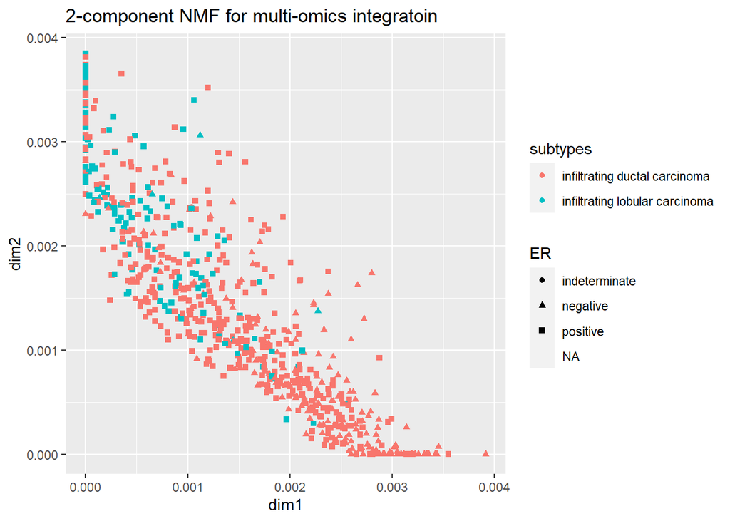

```r
ggplot(nmf_df, aes(x = dim1, y = dim2, color = subtypes, shape = ER)) + geom_point() + ggtitle("2-component NMF for multi-omics integratoin")
```

We were able to separate the patients with infiltrating ductal carcinoma from the ones with infiltrating lobular carcinoma. Interestingly, most of the patients with lobular carcinoma are estrogen receptor pisitive, whereas lots of the patients with ductal carcinoma are estrogen receptor negative.

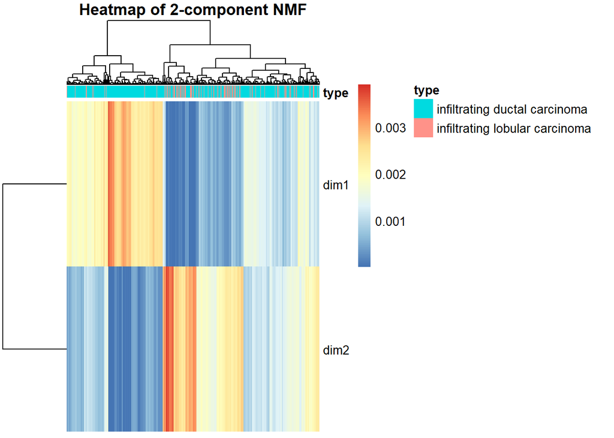

```r
anno_col <- data.frame(type = as.factor(dfcolData$histological.type))
rownames(anno_col) <- rownames(dfcolData)
pheatmap(t(nmf_df[,1:2]),annotation_col = anno_col, show_colnames=FALSE, main="Heatmap of 2-component NMF")
```

The figure above shows that most tumors are driven mainly by one of the factors. Based on this, we will assign each tumor a cluster label by its dominant factor.

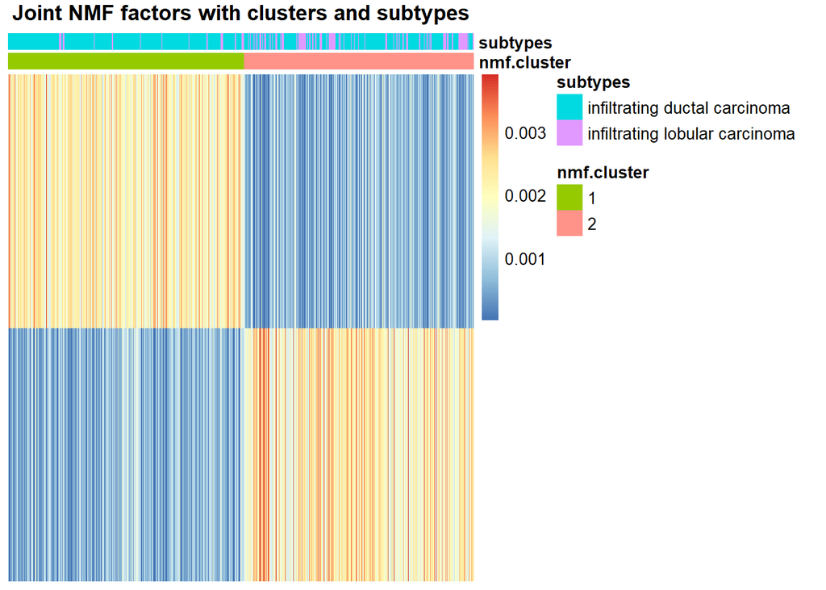

```r
nmf.cluster <- max.col(nmf.h)
names(nmf.cluster) <- rownames(nmf.h)
anno_nmf_cl <- data.frame(nmf.cluster = factor(nmf.cluster), subtypes = factor(dfcolData[rownames(nmf.h),]$histological.type))

pheatmap(t(nmf.h[order(nmf.cluster),]), cluster_cols = F, cluster_rows = F, annotation_col = anno_nmf_cl,
         show_colnames = F, main = "Joint NMF factors with clusters and subtypes")
```

Using one-hot clustering with Joint NMF, two clusters showed up in the data, which are fairly relevant to the histological subtypes of tumors.

## Biological Interpretation

By looking at the coefficients of the latent factors, we can find out which multi omics features are co-regulated.

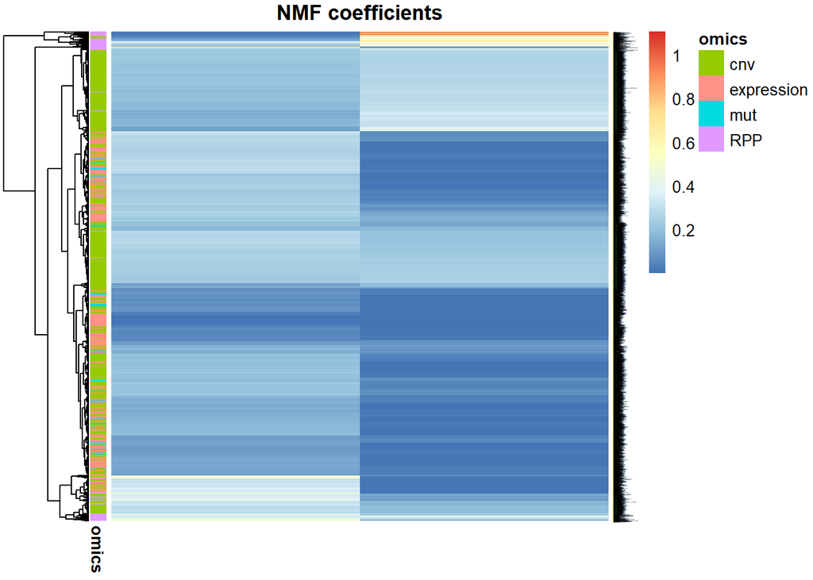

```r
nmfw <- t(nmf.w)
data_anno <- data.frame(omics=c(rep('expression',dim(dataList$RS)[2]), rep('mut',dim(dataList$MU)[2]),
                                rep('cnv',dim(CN.nonneg)[1]), rep("RPP", dim(PP.nonneg)[1])))
rownames(data_anno) <- c(rownames(t(dataList$RS)), paste0("mut:", rownames(t(dataList$MU))),paste0("CN:", rownames(CN.nonneg)), rownames(PP.nonneg))
rownames(nmfw) <- rownames(data_anno)

pheatmap::pheatmap(nmfw,
                   cluster_cols = FALSE,
                   annotation_row = data_anno,
                   main="NMF coefficients",
                   clustering_distance_rows = "manhattan",
                   fontsize_row = 1)
```

```r
topExp <- data.frame(nmfw[colnames(dataList$RS),])
colnames(topExp) <- c("F1","F2")
knitr::kable(topExp[order(topExp$F1, decreasing = T),][1:3,])
```

|  | F1 | F2 |
| --- | --- | --- |
| CACNA1H | 0.3657859 | 3e-06 |
| CACNA2D1 | 0.3647759 | 3e-06 |
| C21orf15 | 0.3646834 | 3e-06 |

```r
knitr::kable(topExp[order(topExp$F2, decreasing = T),][1:3,])
```

|  | F1 | F2 |
| --- | --- | --- |
| CCNO | 0.2191502 | 0.1660726 |
| TDRD1 | 0.2186183 | 0.1660380 |
| KRT6C | 0.2171137 | 0.1660158 |

```r
topCN <- data.frame(nmfw[paste0("CN:", rownames(CN.nonneg)),])
colnames(topCN) <- c("F1","F2")
knitr::kable(topCN[order(topCN$F1, decreasing = T),][1:3,])
```

|  | F1 | F2 |
| --- | --- | --- |
| CN:KRT1- | 0.5672224 | 2.0e-06 |
| CN:RDH16- | 0.5219312 | 2.1e-06 |
| CN:NXPH4- | 0.5128769 | 2.2e-06 |

```r
knitr::kable(topCN[order(topCN$F2, decreasing = T),][1:3,])
```

|  | F1 | F2 |
| --- | --- | --- |
| CN:KLK11+ | 0.0215764 | 0.4876339 |
| CN:DPYSL4+ | 0.0266611 | 0.4792947 |
| CN:ASCL2+ | 0.0475359 | 0.4536292 |

```r
topMU <- data.frame(nmfw[paste0("mut:", colnames(dataList$MU)),])
colnames(topMU) <- c("F1","F2")
knitr::kable(topMU[order(topMU$F1, decreasing = T),][1:3,])
```

|  | F1 | F2 |
| --- | --- | --- |
| mut:MGA | 0.296985 | 0.0106440 |
| mut:SYNE1 | 0.296528 | 0.0096034 |
| mut:LRBA | 0.295514 | 0.0081020 |

```r
knitr::kable(topMU[order(topMU$F2, decreasing = T),][1:3,])
```

|  | F1 | F2 |
| --- | --- | --- |
| mut:FRMPD4 | 0.2045231 | 0.1279549 |
| mut:DCHS2 | 0.2045231 | 0.1279549 |
| mut:PAPPA2 | 0.2115104 | 0.1273510 |

```r
topPP <- data.frame(nmfw[rownames(PP.nonneg),])
colnames(topPP) <- c("F1","F2")
knitr::kable(topPP[order(topPP$F1, decreasing = T),][1:3,])
```

|  | F1 | F2 |
| --- | --- | --- |
| Cyclin.E1+ | 0.9590526 | 1.2e-06 |
| FoxM1+ | 0.8849471 | 1.3e-06 |
| ASNS+ | 0.8532654 | 1.3e-06 |

```r
knitr::kable(topPP[order(topPP$F2, decreasing = T),][1:3,])
```

|  | F1 | F2 |
| --- | --- | --- |
| Caspase.3- | 1e-06 | 1.107260 |
| SCD- | 1e-06 | 1.089570 |
| Myosin.IIa- | 1e-06 | 1.063883 |

By inspecting the features, we see that gene expression and mutation dominate only one factor, whereas copy number and phase protein dominate both factors. As shown above, the first factor is associated with high expression of CACNA1H, CACNA2D1, and C21orf15 genes, loss of KRT1, RDH16, and NXPH4 copy numbers, frequent mutation of MGA, SYNE1, and LRBA, and higher level of Cyclin.E1, FOXM1, and ASNS proteins. Second factor is associated with the gain in copy number of KLK11, DPYSL, and ASCL2, and decrease in Caspase3, SCD, and MyosinIIa proteins.

## Enrichment Analysis

To show that the genes associated with a factor (here factor one) significantly overlap the genes in a biological process, we will apply the hypergeometric enrichment test (Fisher’s one-sided exact test).

```r
# gene expression affect only the first factor

genes.factor <- rownames(topExp[order(topExp$F1, decreasing = T),][1:100,])# analysis for top 100 genes
go.factor <- enrichr(genes.factor, databases = c("GO_Biological_Process_2018"))$GO_Biological_Process_2018
```

```
## Uploading data to Enrichr... Done.
##   Querying GO_Biological_Process_2018... Done.
## Parsing results... Done.
```

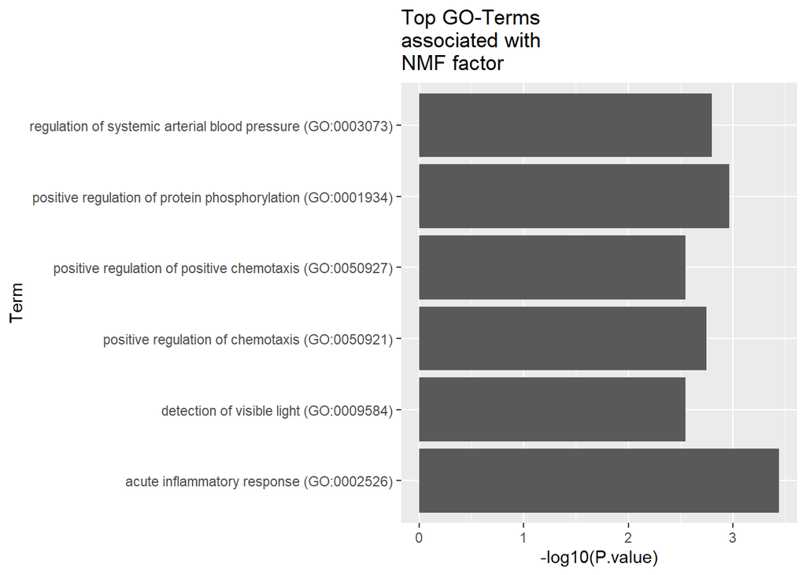

```r
ggplot(head(go.factor), aes(y=-log10(P.value), x = Term))+
  geom_bar(stat = "identity") + coord_flip() + ggtitle("Top GO-Terms\nassociated with\nNMF factor")
```

We confirmed that the expression of the genes associated with the first factor are significantly overlapping the biological pathways, such as acute inflamatory response, regulation of protein phosphorylation, and the regulation of chemotaxis.